# A-21047-final

### Qs

I develop these function with the exact name and parameters on them, so they are not including much notations for you.

```
## [1] 2000
## [1] 1.167122
```

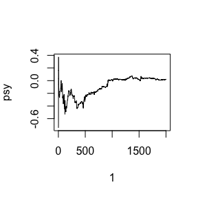

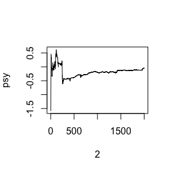

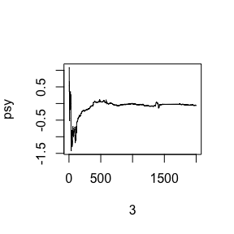

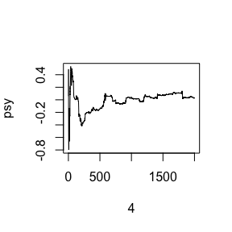

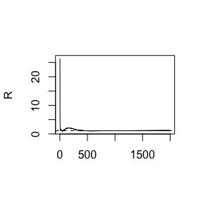

```
## [1] 4000
## [1] 1.13095
```

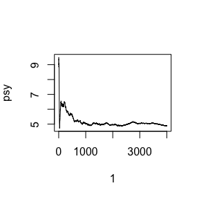

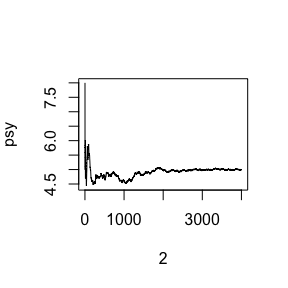

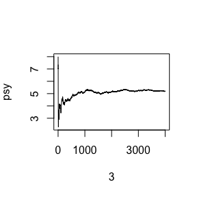

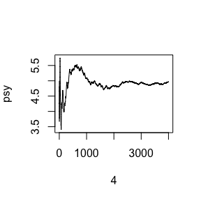

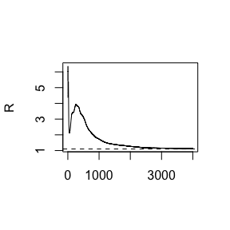

```
## [1] 6000
## [1] 1.118323
```

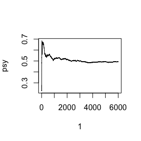

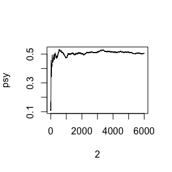

[3 more figures not shown]

```r
cp_GeRu_func <- function(psy){
  psy <- as.matrix(psy)
  num_col <- ncol(psy)
  num_row <- nrow(psy)

  mean_of_psy <- rowMeans(psy)
  var_bewteen_chains <- num_col * var(mean_of_psy)
  vars_within_chains <- apply(psy, 1, "var")
  var_estimate_within_chains <- mean(vars_within_chains)
  var_estimate_upper <- var_estimate_within_chains * (num_col-1)/num_col + var_bewteen_chains/num_col
  GeRu_stat <- var_estimate_upper/var_estimate_within_chains
  return(GeRu_stat)
}

# all generation for chains
cp_chains_generaton <- function(num_of_chains=4,length_of_chains=1e4, method="v1",x0=NA){
  x1 <- matrix(0,nrow = num_of_chains, ncol = length_of_chains)
  for (n_o_c in 1:num_of_chains){
    x1[n_o_c,] <- switch (method,
      "v1" = cp_mc_random_v1(length_of_chains,x0 = x0[n_o_c])[-1],
      "v2" = cp_mc_random_v2(length_of_chains,x0 = x0[n_o_c])[-1],
      "v3" = cp_gibbs(length_of_chains,mu_xy = c(x0[n_o_c,]))[,1],
      "v4" = cp_gibbs(length_of_chains,mu_xy = c(x0[n_o_c,]))[,2]
    )
  }
  return(x1)
}

#x1 <- cp_chains_generaton()

cp_psy_calculation <- function(x){
  # compute diagnostic statistics for x1 and x2
  psy <- t(apply(x1, 1, cumsum))
  for (i in 1:nrow(psy)){
    psy[i,] <- psy[i,] / (1:ncol(psy))
  }
  return(psy)
}

#psy <- cp_psy_calculation(x1)[1]

cp_plot_chains <- function(psy,length_of_chains=ncol(psy),num_of_chains=4){
  #par(mfrow=c(2,2))
  for (i in 1:4){
    plot(psy[i,],type="l",xlab=i,ylab=bquote(psy))
  }
  #par(mfrow=c(1,1))
}

# cp_plot_chains(psy)

cp_plot_r_hat <- function(psy,length_of_chains=ncol(psy)){
  rhat <- rep(0,length_of_chains)
  for (j in 1:length_of_chains){
    rhat[j] <- cp_GeRu_func(psy[,1:j])
  }
  plot(rhat[1:length_of_chains],type = "l",xlab="",ylab="R")
  abline(h=1.1,lty=2)
}

# Finally We draw this pic altogether
method = c("v1","v2","v3","v4")[-2] # ignore v2
GeRu_of_convergiance <- chain_length_of_convergiance <- numeric(length(method))

for (me in 1:length(method)){
  method_use = method[me]
  x0 <- switch (method_use,
    'v1' = c(NA,1,2,3),
    # 'v2' = c(NA,-1,1,10),
    'v3' = matrix(c(1,0.5,1,0.5,1,0.5,1,0.5),ncol = 2,nrow = 4),
    'v4' = matrix(c(1,0.5,1,0.5,1,0.5,1,0.5),ncol = 2,nrow = 4)
  )
  length_of_chains <- 1000

  for (turn in 1:10){
    x1 <- cp_chains_generaton(length_of_chains = length_of_chains, method = method_use,x0 = x0)
    psy <- cp_psy_calculation(x1)
    cp_dias <- cp_GeRu_func(psy)

    if (cp_dias < 1.2){
      chain_length_of_convergiance[me] <- length_of_chains
      print(length_of_chains)
      GeRu_of_convergiance[me] <- cp_dias
      print(cp_dias)
      cp_plot_chains(psy)
      cp_plot_r_hat(psy)
      break
    } else {
      length_of_chains <- length_of_chains + 1e3
    }
  }
}
```

We could see that within 10000, the Markov chain get convergiance with $\hat R < 1.2$.

For method 1 in Exe 9.3, the length is 2000 with $\hat{R}=$ 1.1671216;For method 3 in Exe 9.8, the length of $X$ is 4000 with $\hat{R}=$ 1.1309503, the length of $Y$ is 6000 with $\hat{R}=$ 1.1183227.

## Questions 2021-11-18

### 11.3

1. Write a function to compute the $k^{th}$ term in
   $$\sum\limits_{k=0}^{\infty}\frac{(-1)^{k}}{k!2^{k}}\frac{||a||^{2k+2}}{(2k+1)(2k+2)}\frac{\Gamma(\frac{d+1}{2})\Gamma(k+\frac{3}{2})}{\Gamma(k+\frac{d}{2}+1)}$$
   where $d \geqslant 1$ is an integer, a is a vector in $\mathbb{R}^{d}$, and $||\cdot ||$ denotes the Euclidean norm. Perform the arithmetic so that the coefficients can be computed for (almost) arbitrarily large k and d. (This sum converges for all $a \in \mathbb{R}^d$).
2. Modify the function so that it computes and returns the sum.
3. Evaluate the sum when $a = (1, 2)^T$ .

### 11.5

Write a function to solve the equation

$$\frac{2\Gamma(\frac{k}{2})}{\sqrt{\pi(k-1)}\Gamma(\frac{k-1}{2})}\int_{0}^{c_{k-1}}(1+\frac{u^{2}}{k-1})^{-k/2}du = \frac{2\Gamma(\frac{k+1}{2})}{\sqrt{\pi k}\Gamma(\frac{k}{2})}\int_0^{c_k}(1+\frac{u^2}{k})^{-(k+1)/2} du$$
for a, where $c_{k}=\sqrt{\frac{a^{2}k}{k+1-a^{2}}}$. Compare the solutions with the points A(k) in Exercise 11.4.

### Qs

Suppose $T_1,\cdots,T_n$ are $i.i.d.$ samples drawn from the exponential distribution with expectation $\lambda$. Those values greater than $\tau$ are not observed due to right censorship, so that the observed values are $Y_i = T_iI(T_i \leqslant \tau) + \tau I(T_i > \tau),i = 1,...,n.$ Suppose $\tau = 1$ and the observed $Y_i$ values are as follows:
$$0.54, 0.48, 0.33, 0.43, 1.00, 1.00, 0.91, 1.00, 0.21, 0.85$$
Use the E-M algorithm to estimate $\lambda$, compare your result with the observed data MLE (note: $Y_i$ follows a mixture distribution).

## Answers

### 11.3

1. We change a little bit to make the computer compute faster.
   $$\begin{aligned}
   \sum\limits_{k=0}^{\infty}(-1)^kL(k,a) & = \sum\limits_{k=0}^{\infty}\frac{(-1)^{k}}{k!2^{k}}\frac{||a||^{2k+2}}{(2k+1)(2k+2)}\frac{\Gamma(\frac{d+1}{2})\Gamma(k+\frac{3}{2})}{\Gamma(k+\frac{d}{2}+1)}\\
   &=\sum\limits_{k=0}^{\infty}\frac{(-1)^{k}}{k!2^{k}}\frac{||a||^{2k+2}}{(2k+1)(2k+2)}\frac{\Gamma(\frac{d+1}{2})\Gamma(k+\frac{3}{2})(k+\frac{d}{2}+1)}{\Gamma(k+\frac{d}{2}+2)}\\
   &=\sum\limits_{k=0}^{\infty}\frac{(-1)^{k}}{k!2^{k}}\frac{||a||^{2k+2}}{(2k+1)(2k+2)}Beta(\frac{d+1}{2},k+\frac32)(k+\frac{d}{2}+1)\\
   \end{aligned}$$

```r
# the kth value needs to be calculated seperately because each of them was too large. It can be calculated easily by twins.
L0 <- function(a,k){
  norm_a <- sqrt(t(a) %*% a)
  #norm_a <- norm(a)
  d <- length(a)
  denominator <- (-1)^k * norm_a ^{2 *k +2} * gamma((d+1)/2) * gamma(k+3/2)
  nominator <- factorial(k) * 2^k * (2*k +1) * (2*k+2) * gamma(k+d/2+1)
  L = denominator / nominator
  return(L)
}

L0(matrix(22,1),10)
```

```
##              [,1]
## [1,] 1.988813e+17
```

```r
L0(100,100)
```

```
##      [,1]
## [1,]  NaN
```

We need one standard answer to check out.

```r
# first calculate the left small number
L_k_of_left <- function(a,k){
  norm_a <- sqrt(t(a)%*%a)
  Lkol <- (2*k+2)*log(norm_a) - log(factorial(k)) - k*log(2)-log(2*k+1)-log(2*k+2)
  return(exp(Lkol))
}

#Then calculate the whole part
L_a_k <- function(a,k){
  d <- length(a)
  lkol <- L_k_of_left(a,k)
  lak <- lkol*(-1)^k * beta((d+1)/2,k+3/2) * (k+d/2+1)
  return(lak)
}

L_a_k(matrix(22,1),10)
```

```
##              [,1]
## [1,] 1.988813e+17
```

```r
L_a_k(100,100)
```

```
##              [,1]
## [1,] 2.08185e+211
```

You can see the modified algorithm can get the same answer as the original one, and more efficiently.

2. for a serial of k, get the result, and set the break if the accuracy get less than $10^{-8}$

```r
sum_of_L_a_k <- function(a, echo = FALSE){
  epsilon <- 10^{-8}
  k = 0
  sum_of_lak = 0
  while (abs(L_a_k(a,k)) > epsilon) {
    sum_of_lak <- sum_of_lak + L_a_k(a,k)
    k <- k + 1
  }
  if(echo){
    print(k)
  }
  return(sum_of_lak)
}

sum_of_L_a_k(50)
```

```
##               [,1]
## [1,] 7.745518e+217
```

3. Based on the function defined above we finally evaluate the result.

```r
a <- matrix(c(1,2),ncol = 1)
sum_of_L_a_k(a)
```

```
##          [,1]
## [1,] 1.532164
```

### 11.5

The $a^2$ are symmetrical for $\pm a$ and $a=0$ is the root. so we only have to solve the function in positive situation.

```r
# the ck value
c_k <- function(a,k){
  res <- sqrt(a^2 * k / (k+1-a^2))
  return(res)
}

# the parameters in front of the function
param <- function(k){
  res <- 2 * exp(lgamma((k+1)/2) - lgamma(k/2) - log(pi*k)/2)
  return(res)
}

# the integrated function
inte_func <- function(a,k){
  res <- exp(- (k+1)/2 * log(1+a^2/k))
  return(res)
}

# part of the function with k
half_func <- function(a,k){
  res <- param(k) * integrate(inte_func, 0, c_k(a,k), rel.tol=.Machine$double.eps^0.25, k = k)$value
  return(res)
}

solve_func_without_math <- function(k = 4){
  Final <- function(a){
    half_func(a,k) - half_func(a,k-1)
  }
  y <- 1:999/1000
  y <- sqrt(k)*y
  sj <- numeric(length(y))
  for(i in 1:length(y)){
    sj[i] <- Final(y[i])
  }
  for (i in 1:(length(sj)-1)) {
      if(sj[i] * sj[i+1] < 0){
      return(uniroot(Final,c(y[i], y[i+1]))$root )
      }

  }
}

solve_func_without_math(k=10)
```

```
## [1] 1.625411
```

The value in 11.4 we can get by the following code

```r
P_k <- function(a,k){
  p <- 1 - pt(c_k(a,k),k)
  return(p)
}

S_func <- function(a,k){
  s <- P_k(a,k) - P_k(a,k-1)
  return(s)
}

solve_func <- function(k = 2){
  ssfunc <- function(a){
    ssf <- P_k(a,k) - P_k(a,k-1)
    return(ssf)
  }
  y <- 1:999/1000
  y <- sqrt(k)*y
  sj <- ssfunc(y)
  epsilon <- 10^{-8}

  for (i in 1:length(sj)) {
    if(i != length(sj)){
      if(sj[i] * sj[i+1] < 0){
      return(uniroot(ssfunc,c(y[i],y[i+1]))$root )
    }
  }
}
}
```

We caompare them together

```r
ks <- c(4:25,100,500,1000)
res1 <- res2 <- numeric(length(ks))
for(i in 1:length(ks)){
  res1[i] <- solve_func(k=ks[i])
  res2[i] <- solve_func_without_math(k=ks[i])
}
matrix(c(ks,res1,res2),ncol = 3)
```

```
##       [,1]     [,2]     [,3]
##  [1,]    4 1.492103 1.492103
##  [2,]    5 1.533559 1.533559
##  [3,]    6 1.562774 1.562774
##  [4,]    7 1.584429 1.584429
##  [5,]    8 1.601182 1.601182
##  [6,]    9 1.614517 1.614517
##  [7,]   10 1.625411 1.625411
##  [8,]   11 1.634410 1.634410
##  [9,]   12 1.642045 1.642045
## [10,]   13 1.648541 1.648541
## [11,]   14 1.654175 1.654175
## [12,]   15 1.659099 1.659099
## [13,]   16 1.663434 1.663434
## [14,]   17 1.667286 1.667286
## [15,]   18 1.670726 1.670726
## [16,]   19 1.673817 1.673817
## [17,]   20 1.676615 1.676615
## [18,]   21 1.679157 1.679157
## [19,]   22 1.681475 1.681475
## [20,]   23 1.683595 1.683595
## [21,]   24 1.685547 1.685547
## [22,]   25 1.687351 1.687351
## [23,]  100 1.720604 1.720604
## [24,]  500 1.729746 1.729746
## [25,] 1000 1.730897 1.730897
```

They are close with the same k.

### Qs

First of all, let me demonstrate this situation in the following math forms:
$$\left\{
\begin{aligned}
T_i &= Y_i, i = 1,2,\cdots,k, T_i<1\\
T_i &\geqslant 1, i = k+1,\cdots,n
\end{aligned}
\right.$$
For $T \sim E(\lambda)$, $f(t_i,\lambda) = \lambda e^{-\lambda t_i}, t_i >0$

Then $L(t,\lambda) = \prod\limits_{i=1}^{n}f(t_i,\lambda) = \lambda^{n} e^{-\lambda\sum\limits_{i=1}^{n}t_i}$, and so $\ln L(t,\lambda) = n\ln \lambda-\lambda\sum\limits_{i=1}^{n}t_i$

E-step: $E[\ln L(t,\lambda)|Y,\lambda_0]=n\ln\lambda-\lambda\sum\limits_{i=1}^{n}E(t_{i}|Y,\lambda_0)$

Now check the value:
$$\begin{aligned}
\sum\limits_{i=1}^{n}E(t_{i}|Y,\lambda_0) &= \sum\limits_{i=1}^{k}E(t_{i}|Y,\lambda_0) +\sum\limits_{i=k+1}^{n}E(t_{i}|Y,\lambda_0)\\
&= \sum\limits_{i=1}^{k}y_i + \sum\limits_{i=k+1}^{n}\frac{E(t_i,t_i\geqslant1,\lambda_0)}{p(t_i\geqslant1,\lambda_0)}\\
&= \sum\limits_{i=1}^{k}y_i + \sum\limits_{i=k+1}^{n}\frac{\int_{1}^{+\infty}x_i\lambda_0e^{-\lambda_0x_i}dx_i}{e^{-\lambda_0}}\\
&= \sum\limits_{i=1}^{k}y_i + \sum\limits_{i=k+1}^{n}\frac{(1+\frac{1}{\lambda_0})e^{-\lambda_0}}{e^{-\lambda_0}}\\
&= \sum\limits_{i=1}^{k}y_i + \sum\limits_{i=k+1}^{n}(1+\frac{1}{\lambda_0})\\
&= \sum\limits_{i=1}^{n}y_i + \frac{n-k}{\lambda_0}
\end{aligned}$$

M-step: $\arg\max\limits_{\lambda}E[\ln L(t,\lambda)|Y,\lambda_0]$

Get the partial devariate in regard to $\lambda$, which means

$\frac{n}{\lambda}-\sum\limits_{i=1}^{n}E(t_{i}|Y,\lambda_0)=0$, we will get the formula: $\frac{n}{\lambda}- (\sum\limits_{i=1}^{n}y_i + \frac{n-k}{\lambda_0}) = 0$, solve this function for $\lambda$, then we’ll get $\lambda_1 = \frac{n}{\sum\limits_{i=1}^{n}y_i + \frac{n-k}{\lambda_0}}$, when $\lambda_1 \rightarrow \lambda_0$

The $\lambda$ equals $\lambda = \frac{k}{\sum\limits_{i=1}^{n}y_i}$, since $k=7$, then the $\lambda = \frac{7}{\sum\limits_{i=1}^{10} y_i}$

The MLE for this problem:

Observation: $L(t,\lambda) = \lambda^7e^{-\lambda\sum\limits_{i=1}^{7}y_i}(e^{-\lambda})^3$, and the $\ln L(t,\lambda) = 7\ln \lambda -\lambda\sum\limits_{i=1}^7 y_i - 3\lambda$ Get the derivative for $\lambda$, then $\frac{7}{\lambda} - \sum\limits_{i=1}^{7}y_i -3 = 0$ then $\lambda = \frac{7}{\sum\limits_{i=1}^7+3} = \frac{7}{\sum\limits_{i=1}^{10}y_i}$. that is identical to the EM result.

We can get the estimator easily by calculation:
$$\lambda = \frac{7}{0.54+ 0.48+ 0.33+ 0.43+ 1.00+ 1.00+ 0.91+ 1.00+ 0.21+ 0.85} = \frac{7}{6.75} = 1.037$$

```r
Y <- c(0.54, 0.48, 0.33, 0.43, 1.00, 1.00, 0.91, 1.00, 0.21, 0.85)
# we choose the frequency of Y >= 1 to estimate lambda as lambda0
# which means 0.3 = e^{-\lambda}
lambda0 <- - log(0.3)

N <- 1000
n <- 10
k <- 7
for(j in 1:N){
  lambda1 <- n/(sum(Y) + (n-k)/lambda0)
  if(abs(lambda1 - lambda0) < 10^{-8}){
    iter <- j
    print(c(j,lambda1))
    break
  } else {
    lambda0 <- lambda1
  }
}
```

```
## [1] 15.000000  1.037037
```

```r
lambda2 <- 1/lambda1
```

Finally, we use EM algorithm to estimate this $\lambda$ in only 15 step and the final result is 1.037037. We find the expectation is $\lambda$ so the parameter is $\frac{1}{\lambda}$, so the answer is 0.9642857

## Questions 2021-11-25

### Exercises 1 in Advanced R. p204

Why are the following two invocations of lapply() equivalent?

```r
trims <- c(0, 0.1, 0.2, 0.5)
x <- rcauchy(100)
lapply(trims, function(trim) mean(x, trim = trim))
lapply(trims, mean, x = x)
```

### Exercises 5 in Advanced R. p204

For each model in the previous two exercises, extract R2 using the function below.

```r
rsq <- function(mod) summary(mod)$r.squared
```

### Exercises 1 in Advanced R. p214

1. Use vapply() to:
1. Compute the standard deviation of every column in a numeric data frame.
2. Compute the standard deviation of every numeric column in a mixed data frame. (Hint: you’ll need to use vapply() twice.)

### Exercises 7 in Advanced R. p214

Implement mcsapply(), a multicore version of sapply(). Can you implement mcvapply(), a parallel version of vapply()? Why or why not?

## Answers

### Exercises 1 in Advanced R. p204

```r
trims <- c(0, 0.1, 0.2, 0.5)
x <- rcauchy(100)
lapply(trims, function(trim) mean(x, trim = trim))
```

```
## [[1]]
## [1] -1.239502
##
## [[2]]
## [1] -0.06557029
##
## [[3]]
## [1] -0.1030753
##
## [[4]]
## [1] -0.1224196
```

```r
lapply(trims, mean, x = x)
```

```
## [[1]]
## [1] -1.239502
##
## [[2]]
## [1] -0.06557029
##
## [[3]]
## [1] -0.1030753
##
## [[4]]
## [1] -0.1224196
```

The first invocation is easy to understand and common used. In the later form, because the mean function takes one optional parameter “trim” in the second invocation, which is redefined in the function as an inner input, for every value in “trims” lapply do the “mean” function for the data “x”. All of this are written in the user R documentation.

You can use the following forms to calculate the sum.

```r
trims <- c(1, 2, 3, 4)
x <- rcauchy(100)
lapply(trims, function(trim) sum(x, trim = trim))
```

```
## [[1]]
## [1] -48.88726
##
## [[2]]
## [1] -47.88726
##
## [[3]]
## [1] -46.88726
##
## [[4]]
## [1] -45.88726
```

```r
lapply(trims, sum, x)
```

```
## [[1]]
## [1] -48.88726
##
## [[2]]
## [1] -47.88726
##
## [[3]]
## [1] -46.88726
##
## [[4]]
## [1] -45.88726
```

```r
# here the sum function takes trims as the optional parameter in the end
```

### Exercises 5 in Advanced R. p204

#### model in Exercise 3

```r
formulas <- list(
  mpg ~ disp,
  mpg ~ I(1 / disp),
  mpg ~ disp+wt,
  mpg ~ I(1/disp)+wt
)
# method 1 for loop
models1 <- list()
for(i in 1:4){
  z <- lm(formula = formulas[[i]],mtcars)
  models1[i] <- list(z)
}

# method 2: lapply
models2 <- lapply(formulas,lm,mtcars)

rsq <- function(mod) summary(mod)$r.squared

# R^2 for method 1
lapply(models1, rsq)
```

```
## [[1]]
## [1] 0.7183433
##
## [[2]]
## [1] 0.8596865
##
## [[3]]
## [1] 0.7809306
##
## [[4]]
## [1] 0.8838038
```

```r
# R^2 for method 2
lapply(models2, rsq)
```

```
## [[1]]
## [1] 0.7183433
##
## [[2]]
## [1] 0.8596865
##
## [[3]]
## [1] 0.7809306
##
## [[4]]
## [1] 0.8838038
```

They are identical. And the last one “mpg ~ I(1/disp)+wt” is the most efficient, because the $R^2$ is the largest. In that case, the functon is $mpg = 19.024 + 1142.560 I(1/disp) -1.798 wt$

#### model in Exercise 4

```r
bootstraps <- lapply(1:10, function(i) {
         rows <- sample(1:nrow(mtcars), rep = TRUE)
         mtcars[rows, ]
})

# method 1 for loop
models3 <- list()
for(i in 1:10){
  z <- lm(formula = mpg ~ disp, bootstraps[[i]])
  models3[i] <- list(z)
}

# method 2 lapply
models4 <- lapply(bootstraps,lm, formula = mpg ~ disp)

rsq <- function(mod) summary(mod)$r.squared

# R^2 for method 1
lapply(models3, rsq)
```

```
## [[1]]
## [1] 0.738232
##
## [[2]]
## [1] 0.7718581
##
## [[3]]
## [1] 0.6216561
##
## [[4]]
## [1] 0.7750088
##
## [[5]]
## [1] 0.6767069
##
## [[6]]
## [1] 0.7167198
##
## [[7]]
## [1] 0.6892343
##
## [[8]]
## [1] 0.6611819
##
## [[9]]
## [1] 0.6999848
##
## [[10]]
## [1] 0.6812855
```

```r
# R^2 for method 2
lapply(models4, rsq)
```

```
## [[1]]
## [1] 0.738232
##
## [[2]]
## [1] 0.7718581
##
## [[3]]
## [1] 0.6216561
##
## [[4]]
## [1] 0.7750088
##
## [[5]]
## [1] 0.6767069
##
## [[6]]
## [1] 0.7167198
##
## [[7]]
## [1] 0.6892343
##
## [[8]]
## [1] 0.6611819
##
## [[9]]
## [1] 0.6999848
##
## [[10]]
## [1] 0.6812855
```

### Exercises 1 in Advanced R. p214

1. compute the sd of every columns

```r
testdf1 <- data.frame(idx = c(1:12),
                      normrandom = rnorm(12),
                      trandom = rt(12,1),
                      chisqrandom = rchisq(12,1))
testdf1
```

```
##    idx normrandom    trandom  chisqrandom
## 1    1  0.1704475  0.7764806 2.343764e-02
## 2    2  0.4978447  0.8907433 6.071122e+00
## 3    3 -1.2977217  0.3283690 5.115711e-01
## 4    4  0.9250341 -2.4810893 2.614329e+00
## 5    5  1.9242150  0.2074204 2.539918e+00
## 6    6  1.0956436 -1.3049652 7.501116e-02
## 7    7  0.9011002 -0.2904308 1.079161e-05
## 8    8 -1.2914114 25.0412718 5.689394e-01
## 9    9  1.0326013 -0.8790319 5.334057e-02
## 10  10 -0.3879074 -4.8103357 3.379025e-01
## 11  11  1.6771729 -8.0736091 2.955624e+00
## 12  12 -1.3239734  0.8424109 6.493934e+00
```

```r
vapply(testdf1, sd, FUN.VALUE = numeric(1))
```

```
##         idx  normrandom     trandom chisqrandom
##    3.605551    1.155991    8.076959    2.345648
```

2. compute the sd of every columns mixed condition

```r
testdf2 <- data.frame(idx = c(1:12),
                      normrandom = rnorm(12),
                      cnidx = c("一","二","三","四","五","六","七","八","九","十","十一","十二"),
                      trandom = rt(12,1),
                      chisqrandom = rchisq(12,1))
testdf2
```

```
##    idx  normrandom cnidx    trandom  chisqrandom
## 1    1  0.30429049    一  4.9455447 0.0641051040
## 2    2 -0.03798812    二  0.4022210 0.5135625811
## 3    3 -2.01265630    三  0.5211981 0.1742681856
## 4    4 -0.05791953    四  0.4848850 0.0026832164
## 5    5  0.66846592    五 -0.7287279 0.0139642360
## 6    6 -0.07935796    六 -0.3083325 0.5404579996
## 7    7 -0.51004955    七  0.4812296 0.1554217107
## 8    8 -0.09816860    八 17.7343700 0.0120835325
## 9    9  0.54947636    九  0.7414052 2.7061054642
## 10  10 -0.96262436    十  1.0634656 4.3234204688
## 11  11 -0.32584633  十一 -0.1900923 0.0005637066
## 12  12  0.56160891  十二 -0.8787512 0.6957572940
```

```r
# the class of this dataframe is
cla <- vapply(testdf2, class, FUN.VALUE = character(1))
cla
```

```
##         idx  normrandom       cnidx     trandom chisqrandom
##   "integer"   "numeric" "character"   "numeric"   "numeric"
```

```r
# extract the numeric data from dataframe
testdf2num <- testdf2[cla == "numeric"]
testdf2num
```

```
##     normrandom    trandom  chisqrandom
## 1   0.30429049  4.9455447 0.0641051040
## 2  -0.03798812  0.4022210 0.5135625811
## 3  -2.01265630  0.5211981 0.1742681856
## 4  -0.05791953  0.4848850 0.0026832164
## 5   0.66846592 -0.7287279 0.0139642360
## 6  -0.07935796 -0.3083325 0.5404579996
## 7  -0.51004955  0.4812296 0.1554217107
## 8  -0.09816860 17.7343700 0.0120835325
## 9   0.54947636  0.7414052 2.7061054642
## 10 -0.96262436  1.0634656 4.3234204688
## 11 -0.32584633 -0.1900923 0.0005637066
## 12  0.56160891 -0.8787512 0.6957572940
```

```r
# compute the sd of every column
vapply(testdf2num, sd, FUN.VALUE = numeric(1))
```

```
##  normrandom     trandom chisqrandom
##   0.7500102   5.1689795   1.3503155
```

```r
# you can wirte it in one line code or in a function
vapply(testdf2[vapply(testdf2, class, FUN.VALUE = character(1)) == "numeric"],
       sd, FUN.VALUE = numeric(1))
```

```
##  normrandom     trandom chisqrandom
##   0.7500102   5.1689795   1.3503155
```

```r
compute_numeric <- function(df,FUN){
  vapply(df[vapply(df, class, FUN.VALUE = character(1)) == "numeric"],
       sd, FUN.VALUE = numeric(1))
}
compute_numeric(testdf2,sd)
```

```
##  normrandom     trandom chisqrandom
##   0.7500102   5.1689795   1.3503155
```

### Exercises 7 in Advanced R. p214

Based on lapply() and sapple definition, I developed the following code mcsapply() with mclapply.

```r
library(parallel)
# A multicore version of sapply
mcsapply <- function (X, FUN, ..., mc.preschedule = TRUE, mc.set.seed = TRUE,
                      mc.silent = FALSE, mc.cores = getOption("mc.cores", 2L),
                      mc.cleanup = TRUE, mc.allow.recursive = TRUE, affinity.list = NULL,
                      simplify = TRUE, USE.NAMES = TRUE) {

    FUN <- match.fun(FUN)
    answer <- mclapply(X, FUN, ...,
                       mc.preschedule = mc.preschedule, mc.set.seed = mc.set.seed,
                       mc.silent = mc.silent, mc.cores = mc.cores, mc.cleanup = mc.cleanup,
                       mc.allow.recursive = mc.allow.recursive, affinity.list = affinity.list)
    if (USE.NAMES && is.character(X) && is.null(names(answer)))
        names(answer) <- X
    if (!isFALSE(simplify))
        simplify2array(answer, higher = (simplify == "array"))
    else answer
}

# simple example where the multicore version costs more time
b <- list(x = 1:10, y = matrix(1:12, 3, 4))
system.time(sapply(b, sum))
```

```
##  用户  系统  流逝
## 0.001 0.000 0.000
```

```r
system.time(mcsapply(b,sum))
```

```
##  用户  系统  流逝
## 0.005 0.015 0.019
```

```r
# complex example where the multicore version saves more time
jack_df <- function(x){x[-(sample(nrow(x),1)),]}
r2      <- function(model){summary(model)$r.square}
jack_lm <- function(i){r2(lm(mpg ~ I(1/disp)+wt, data = jack_df(mtcars)))}
system.time(sapply(1:5000, jack_lm))
```

```
##  用户  系统  流逝
## 5.293 0.075 5.373
```

```r
system.time(mcsapply(1:5000, jack_lm))
```

```
##  用户  系统  流逝
## 0.012 0.006 4.544
```

The multivore version of the above function has the same properties as the the mclapply(), where it saves time in complex situation while wastes in simple situation for the reason that it has to initialize the parameters needed to do parallelization.

As for the multicore version for vapply(), accprding to the following original code, vapply() and lapply() has the same structure, so the multicore version may has the same complexity which is beyond my ability now. Furthermore the mcsapply() guesses the output format while the mcvapply() has to be appointed, which is the biggest obstacle to overcome. Maybe I can handle this in near feature, but for now I can’t.

```r
###########################
sapply <- function (X, FUN, ..., simplify = TRUE, USE.NAMES = TRUE)
{
    FUN <- match.fun(FUN)
    answer <- lapply(X = X, FUN = FUN, ...)
    if (USE.NAMES && is.character(X) && is.null(names(answer)))
        names(answer) <- X
    if (!isFALSE(simplify))
        simplify2array(answer, higher = (simplify == "array"))
    else answer
}

vapply <- function (X, FUN, FUN.VALUE, ..., USE.NAMES = TRUE)
{
    FUN <- match.fun(FUN)
    if (!is.vector(X) || is.object(X))
        X <- as.list(X)
    .Internal(vapply(X, FUN, FUN.VALUE, USE.NAMES))
}

lapply <- function (X, FUN, ...)
{
    FUN <- match.fun(FUN)
    if (!is.vector(X) || is.object(X))
        X <- as.list(X)
    .Internal(lapply(X, FUN))
}
#########################
```

## Questions 2021-12-02

This example appears in [40]. Consider the bivariate density
$$f(x,y) \propto \lgroup_{x}^{n}\rgroup\cdot y^{x+a-1}(1-y)^{n-x+b-1},x=0,1,\cdots,n,0\leqslant y\leqslant1.$$
It can be shown (see e.g. [23]) that for fixed a, b, n, the conditional distributions are Binomial($n, y$) and Beta($x+a,n−x+b$). Use the Gibbs sampler to generate a chain with target joint density $f(x,y)$.

1. Write an Rcpp function for Exercise 9.8 (page 278, Statistical Computing with R).
2. Compare the corresponding generated random numbers with pure R language using the function “qqplot”.
3. Compare the computation time of the two functions with the function “microbenchmark”.
4. Comments your results.

## 1. I developed this function in R code before.

```r
# The following is the R version
cp_gibbsR <- function(length_of_chains = 1e4,from_point = 1001, a = 1, b = 1, x_range = 10, mu_x = NA, mu_y = NA){
  ## length_of_chains: the whole chain length
  ## from_point: from which point to output, notice we actually generate 1e4 + 1000, because we have to dump the first 1000 points
  ## a, b: they are in the beta parameters
  ## x_range: the n parameter in Binomial(n,y)
  ## mu_x.mu_y: the beginning value of this chain
  to_point = length_of_chains + from_point - 1
  Z <- matrix(0,nrow = to_point,ncol = 2)
  # Z initialize
  if (is.na(mu_x) | is.na(mu_y)){
    # condition 1: x0 is not defined
    Z[1,2] <- a/(a+b)
    Z[1,1] <- x_range * Z[1,2]
  } else {
    # condition 2: x0 is defined
    Z[1,] <- c(mu_x,mu_y)
  }
  for (i in 2:to_point){
    # update X
    Zy <- Z[i-1,2]
    Z[i,1] <- rbinom(1,x_range,Zy)
    # update Y
    Zx <- Z[i,1]
    Z[i,2] <- rbeta(1,Zx+a,x_range-Zx+b)
  }
  return(Z[from_point:to_point,])
}
```

```r
library(Rcpp)
# the following is the C version
# notice: C use 0, R use 1 at the beginning, so something looks different from R version.
cppFunction('
NumericMatrix cp_gibbsC(int length_of_chains=1e4,int from_point=1000,int a =1,int b = 1,int x_range=10,float mu_x = -1,float mu_y= -1) {
  // x,y can not be negative, and the NA is not accepted, so I choose -1 to avoid no initial values.
  int to_point = length_of_chains + from_point;
  NumericMatrix Z(to_point, 2);
  // Initial Value
  if (mu_x == -1 || mu_y == -1){
    Z(0,1) = a/(a+b);
    Z(0,0) = x_range * Z(0,1);
  } else {
    Z(0,0) = mu_x;
    Z(0,1) = mu_y;
  }
  for(int i = 1; i < to_point; i++) {
      // Update x
      float Zy = Z(i-1,1);
      Z(i,0) = rbinom(1,x_range,Zy)[0];
      // Update y
      float Zx = Z(i,0);
      Z(i,1) = rbeta(1,Zx+a,x_range-Zx+b)[0];
  }
  return(Z(Range(from_point,to_point-1),_));
  // 1000 - 10999: 10000 in total.
}
')
```

Now we generate the chains.

```r
ZR <- cp_gibbsR()
ZC <- cp_gibbsC()
```

```r
cp_show_chain <- function(x,from_p = 1, to_p = length(x)){
  idx <- from_p:to_p
  y1 <- x[idx]
  plot(idx,y1,type="l",ylab="x")
}

cp_show_gibbs_stat <- function(Z){
  Z_show <- Z
  col_mean_Z <- colMeans(Z_show)
  cov_Z <- cov(Z_show)
  cor_Z <- cor(Z_show)
  print(col_mean_Z)
  print(cov_Z)
  print(cor_Z)
  plot(Z_show,main = "",cex=0.5,xlab="x",ylab="y",ylim=range(Z_show[,2]))
}
```

Comparison between the chains.

```r
cp_show_gibbs_stat(ZR)
```

```
## [1] 4.8338000 0.4835216
##            [,1]       [,2]
## [1,] 10.1655941 0.85006548
## [2,]  0.8500655 0.08474551
##          [,1]     [,2]
## [1,] 1.000000 0.915857
## [2,] 0.915857 1.000000
```

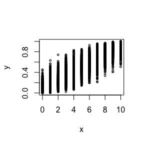

```r
cp_show_gibbs_stat(ZC)
```

```
## [1] 5.2344000 0.5215606
##           [,1]       [,2]
## [1,] 10.000457 0.83369102
## [2,]  0.833691 0.08322284
##          [,1]     [,2]
## [1,] 1.000000 0.913848
## [2,] 0.913848 1.000000
```

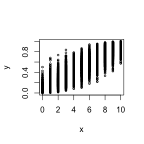

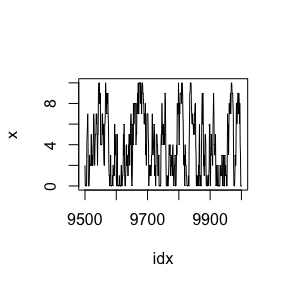

```r
# Result for R version
#par(mfrow=c(2,2))
cp_show_chain(ZR[,1],9500)
```

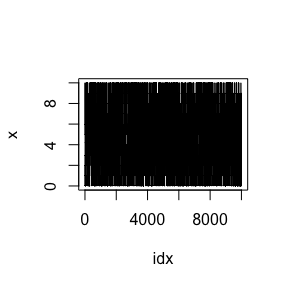

```r
cp_show_chain(ZR[,1])
```

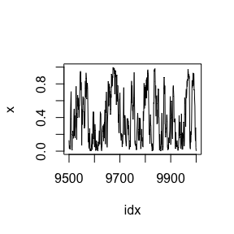

```r
cp_show_chain(ZR[,2],9500)
```

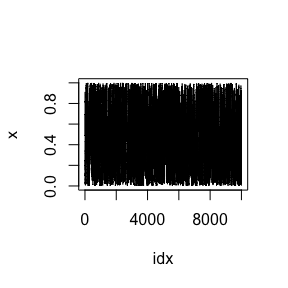

```r
cp_show_chain(ZR[,2])
```

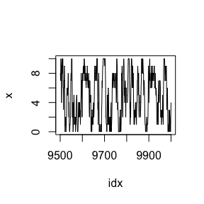

```r
# Result for C version
cp_show_chain(ZC[,1],9500)
```

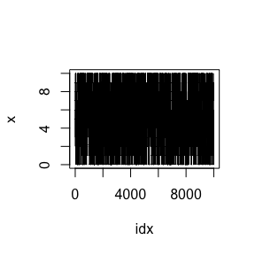

```r
cp_show_chain(ZC[,1])
```

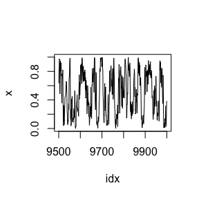

```r
cp_show_chain(ZC[,2],9500)
```

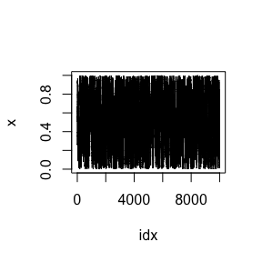

```r
cp_show_chain(ZC[,2])
```

## 2. QQ plot

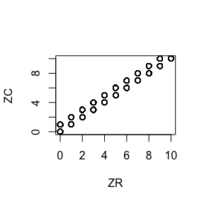

```r
qqplot(ZR[,1],ZC[,1],xlab = "ZR",ylab = "ZC")
```

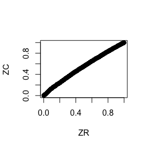

```r
qqplot(ZR[,2],ZC[,2],xlab = "ZR",ylab = "ZC")
```

As we can see, the two versions generate the relative chain convergent at the same point.

## 3. Microbenchmark

```r
library(microbenchmark)
ts <- microbenchmark(ZR=cp_gibbsR(),ZC=cp_gibbsC())
summary(ts)[,c(1,3,5,6)]
```

```
##   expr        lq    median        uq
## 1   ZR 68.059456 77.822602 90.596602
## 2   ZC  4.168807  4.532844  5.227648
```

C version runs faster than R version.

## 4. Comments

The QQ plot show that gibbs C and R version could get similiar chain and converged at the same chain. Furthermore, the C version can get the result faster than R version.